# DATA 605 Final Exam

Samuel I Kigamba

May 20, 2020

Load all the necessary Libraries

```r
library(gridExtra)
library(RColorBrewer)
library(Matrix)
library(scales)
library(corrplot)
library(MASS)
library(psych)
library(ggplot2)
```

Your final is due by the end of the last week of class (5/22/2020). You should post your solutions to your GitHub account or RPubs.  
You are also expected to make a short presentation via YouTube and post that recording to the board. This project will show off your ability to understand the elements of the class.

# Problem 1

Using R, generate a random variable X that has 10,000 random uniform numbers from 1 to N, where N can be any number of your choosing greater than or equal to 6. Then generate a random variable Y that has 10,000 random normal numbers with a mean of:

$$\mu=\sigma=(N+1)/2$$

```r
set.seed(100)

N = 10
n = 10000

# Random Uniform number generation
X = runif(n, 1, N)

# Random normal number generation
Y = rnorm(n, mean = (N+1)/2, sd = (N+1)/2)

dfXY = data.frame(cbind(X, Y))

# View the first 5 numbers generated
dfXY[0:5,1:2]
```

```
##          X        Y
## 1 3.769895 7.849050
## 2 3.319053 4.227292
## 3 5.970902 7.721962
## 4 1.507448 2.475432
## 5 5.216944 1.687728
```

## Probability

Assume the small letter “x” is estimated as the median of the X variable, and the small letter “y” is estimated as the 1st quartile of the Y variable.

```r
# Median of X
x = median(X)
x
```

```
## [1] 5.472943
```

```r
# 1st Quantile of Y
y = quantile(Y, 0.25)
y
```

```
##      25%
## 1.769673
```

Calculate as a minimum the below probabilities a through c. Interpret the meaning of all probabilities.

### a. P(X>x | X>y)

```r
# Number of observations where X is greater than y, the 1st quantile of Y
nXy = nrow(subset(dfXY, X > y))
nXy
```

```
## [1] 9223
```

```r
# Probability of X is higher than x, the median of X given that X is greater than y, the 1st quantile of Y.
pa = nrow(subset(dfXY, X > x & X > y))/nXy
pa
```

```
## [1] 0.542123
```

The probability is 0.54 or 54%

### b. P(X>x, Y>y)

```r
# Probability that both X and Y are greater than x, the median of X and y, the first quantile of Y respectively.
pb = nrow(subset(dfXY, X > x & Y > y))/n
pb
```

```
## [1] 0.3755
```

The probability is 0.3755 or 37.55%

### c. P(X<x | X>y)

```r
# Probability that X is less that x, the median of X given that X is greater than Y
pc = nrow(subset(dfXY, X < x & X > y))/nXy
pc
```

```
## [1] 0.457877
```

The probability is 0.4579 or 45.79%

Investigate whether P(X>x and Y>y) = P(X > x) * P(Y > y) by building a table and evaluating the marginal and joint probabilities.

```r
A1 <- c(sum(X <= x & Y <= y), sum(X > x & Y <= y))
B1 <- c(sum(X <= x & Y > y), sum(X > x & Y > y))

ct_matrix <- matrix(c(A1, B1), nrow = 2)
ct_matrix <- rbind(ct_matrix, apply(ct_matrix, 2, sum))
ct_matrix <- cbind(ct_matrix, apply(ct_matrix, 1, sum))

xy <- c("<=1st quartile", ">1st quartile", "Total")
countDF <- data.frame(xy, ct_matrix)
colnames(countDF) <- c("x/y", "<=1st quartile", ">1st quartile", "Total")
print(countDF)
```

```
##              x/y <=1st quartile >1st quartile Total
## 1 <=1st quartile           1255          3745  5000
## 2  >1st quartile           1245          3755  5000
## 3          Total           2500          7500 10000
```

```r
A <- countDF[2, 4]
B <- countDF[3, 3]
A_B <- countDF[2, 3]
tot <- countDF[3, 4]

Prob_A <- A/tot
Prob_B <- B/tot
prob_A_B <- A_B/tot

print(prob_A_B)
```

```
## [1] 0.3755
```

So P(AB) = 0.3755

```r
Prob_A_Prob_B = Prob_A * Prob_B

print(Prob_A_Prob_B)
```

```
## [1] 0.375
```

So, P(X>x and Y>y)=P(X>x)P(Y>y) is TRUE.

Check to see if independence holds by using Fisher’s Exact Test and the Chi Square Test.  
What is the difference between the two? Which is most appropriate?

```r
# Generate the matrix
Matrix <- matrix(c(A1, B1), nrow = 2)

# Perform the Chi square test
chisq.test(Matrix)
```

```
##
##  Pearson's Chi-squared test with Yates' continuity correction
##
## data:  Matrix
## X-squared = 0.0432, df = 1, p-value = 0.8353
```

```r
# Perform the Fisher's Exact Test
fisher.test(Matrix, simulate.p.value=TRUE)
```

```
##
##  Fisher's Exact Test for Count Data
##
## data:  Matrix
## p-value = 0.8354
## alternative hypothesis: true odds ratio is not equal to 1
## 95 percent confidence interval:
##  0.9222661 1.1076494
## sample estimates:
## odds ratio
##   1.010724
```

# Problem 2

You are to register for Kaggle.com (free) and compete in the House Prices: Advanced Regression Techniques competition. https://www.kaggle.com/c/house-prices-advanced-regression-techniques .  
I want you to do the following.

```r
#Training set
train = read.csv("https://raw.githubusercontent.com/igukusamuel/DATA-605-Final-Project/master/train.csv")
dim(train)
```

```
## [1] 1460   81
```

```r
# Select the variables to perform the various statistical operations
X = train$LotArea
Y = train$SalePrice
Z = train$GarageArea
```

## Descriptive and Inferential Statistics.

Provide univariate descriptive statistics and appropriate plots for the training data set.

Descriptive statistics on LotArea

```r
# Descriptive statistics on LotArea
summary(X)
```

```
##    Min. 1st Qu.  Median    Mean 3rd Qu.    Max.
##    1300    7554    9478   10517   11602  215245
```

```r
describe(X)
```

```
##    vars    n     mean      sd median trimmed     mad  min    max  range
## X1    1 1460 10516.83 9981.26 9478.5 9563.28 2962.23 1300 215245 213945
##     skew kurtosis     se
## X1 12.18   202.26 261.22
```

*There are 1460 obsevarions with LotArea ranging from 1300SF to 215,245SF. The average LotArea is 10,516SF.*

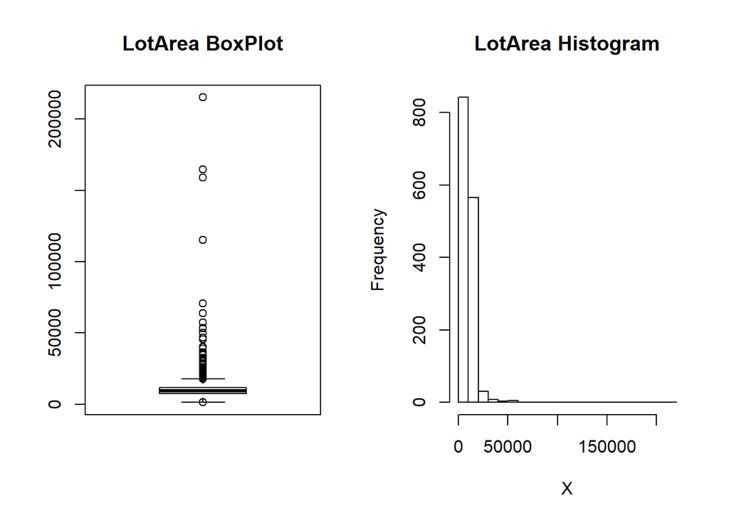

```r
# BoxPlot and Histograms for the LotArea
par(mfrow=c(1,2))
boxplot(X, main="LotArea BoxPlot")
hist(X, breaks = 20, main = "LotArea Histogram")
```

*The distribution of the LotArea is right skewed with a alot of outliers.*

Descriptive statistics on SalePrice

```r
# Descriptive statistics on SalePrice
summary(Y)
```

```
##    Min. 1st Qu.  Median    Mean 3rd Qu.    Max.
##   34900  129975  163000  180921  214000  755000
```

```r
describe(Y)
```

```
##    vars    n     mean      sd median  trimmed     mad   min    max  range
## X1    1 1460 180921.2 79442.5 163000 170783.3 56338.8 34900 755000 720100
##    skew kurtosis      se
## X1 1.88      6.5 2079.11
```

*There are 1460 obsevarions with SalePrice ranging from $34,900 to $755,000. The average SalePrice is $180,921.*

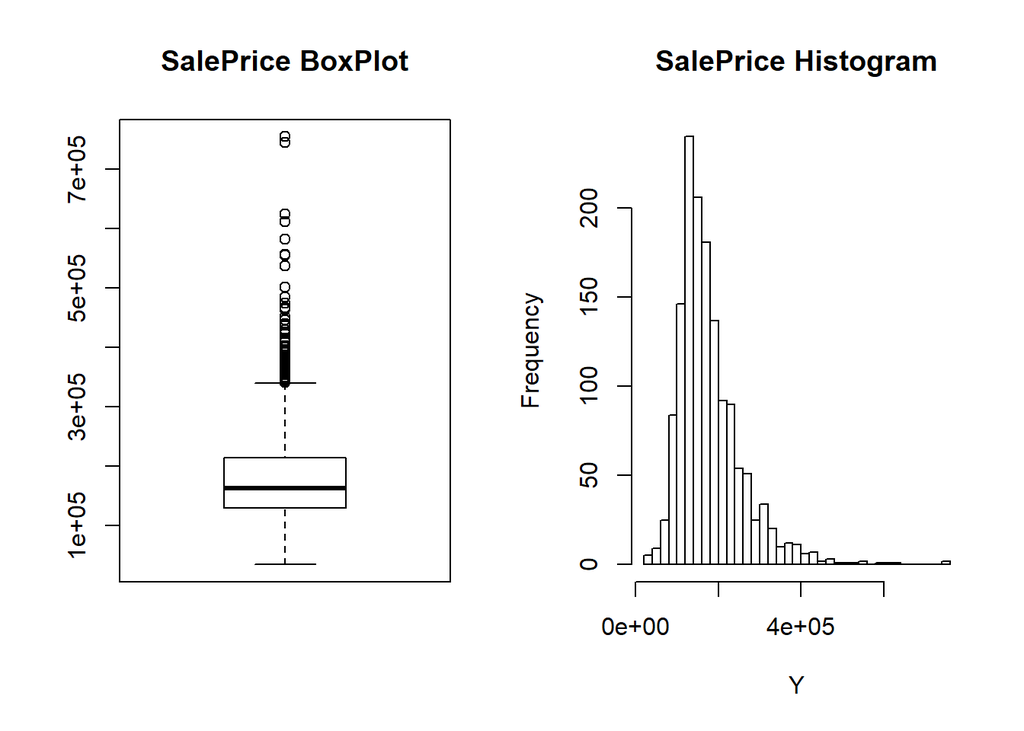

```r
# BoxPlot and Histograms for the SalePrice
par(mfrow=c(1,2))
boxplot(Y, main="SalePrice BoxPlot")
hist(Y, breaks = 30, main = "SalePrice Histogram")
```

Descriptive statistics on GarageArea

```r
# Descriptive statistics on GarageArea
summary(Z)
```

```
##    Min. 1st Qu.  Median    Mean 3rd Qu.    Max.
##     0.0   334.5   480.0   473.0   576.0  1418.0
```

```r
describe(Z)
```

```
##    vars    n   mean    sd median trimmed    mad min  max range skew
## X1    1 1460 472.98 213.8    480  469.81 177.91   0 1418  1418 0.18
##    kurtosis  se
## X1      0.9 5.6
```

*There are 1460 obsevarions with GarageArea ranging from 0SF to 1,418SF. The average GarageArea is 473SF.*

BoxPlot and Histograms for the GarageArea

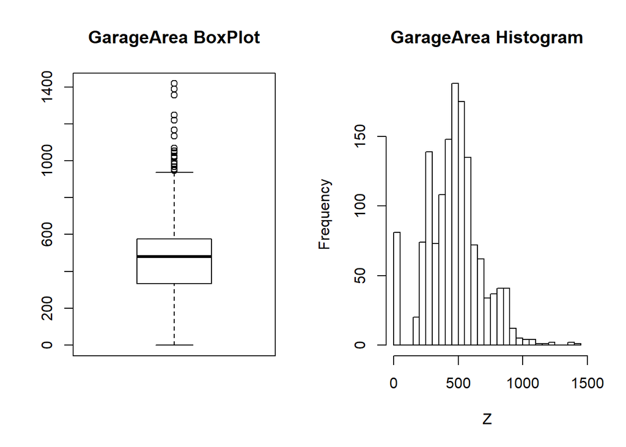

```r
# BoxPlot and Histograms for the GarageArea
par(mfrow=c(1,2))
boxplot(Z, main="GarageArea BoxPlot")
hist(Z, breaks = 30, main = "GarageArea Histogram")
```

*The distribution of the GarageArea is right skewed with a few observable outliers.*

Provide a scatterplot matrix for at least two of the independent variables and the dependent variable.

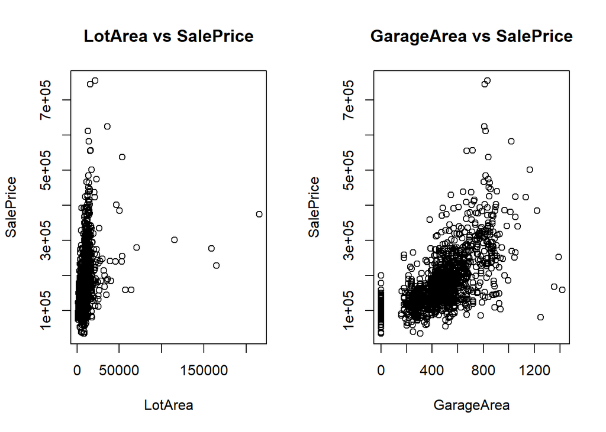

```r
# Scatterplot of LotArea and GarageArea vs SalePrice
par(mfrow=c(1,2))
plot(X, Y, xlab="LotArea", ylab="SalePrice", main="LotArea vs SalePrice")
plot(Z, Y, xlab="GarageArea", ylab="SalePrice", main="GarageArea vs SalePrice")
```

Derive a correlation matrix for any three quantitative variables in the dataset.

```r
corDF = train[c("LotArea", "GarageArea", "SalePrice")]
corMatrix = cor(corDF, use = "complete.obs")
print(corMatrix)
```

```
##              LotArea GarageArea SalePrice
## LotArea    1.0000000  0.1804028 0.2638434
## GarageArea 0.1804028  1.0000000 0.6234314
## SalePrice  0.2638434  0.6234314 1.0000000
```

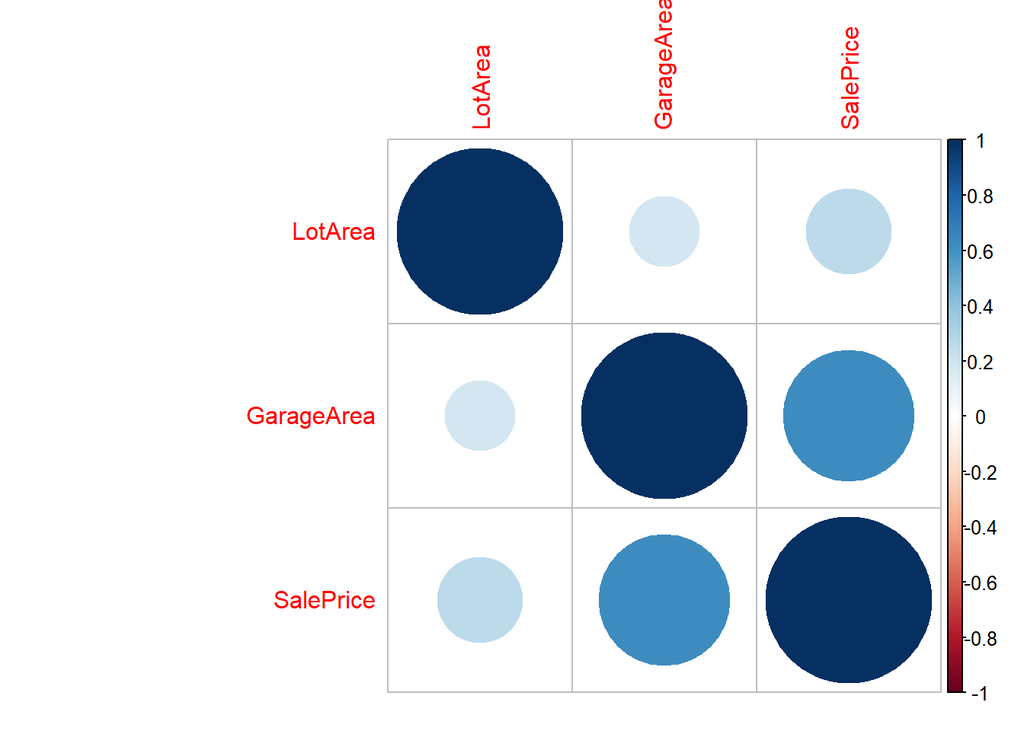

```r
#visualize the correlation matrix
corrplot(corMatrix, method = "circle")
```

*From the corellation matrix we can conclude that there exist strong to weak correlation between the three variables* *SalePrice has a strong corellation with GarageArea and a weak corellation with LotArea with corellation coefficient of 0.62 and 0.26 respectively.* *LotArea and GarageArea have weak corellation with each other with a correlation coefficieant of 0.18.*

Test the hypotheses that the correlations between each pairwise set of variables is 0 and provide an 80% confidence interval.

```r
# Pairwise corelation between LotArea and SalePrice
cor.test(corDF$LotArea, corDF$SalePrice, method = 'pearson', conf.level = 0.80)
```

```
##
##  Pearson's product-moment correlation
##
## data:  corDF$LotArea and corDF$SalePrice
## t = 10.445, df = 1458, p-value < 2.2e-16
## alternative hypothesis: true correlation is not equal to 0
## 80 percent confidence interval:
##  0.2323391 0.2947946
## sample estimates:
##       cor
## 0.2638434
```

```r
# Pairwise corelation between GarageArea and SalePrice
cor.test(corDF$GarageArea, corDF$SalePrice, method = 'pearson', conf.level = 0.80)
```

```
##
##  Pearson's product-moment correlation
##
## data:  corDF$GarageArea and corDF$SalePrice
## t = 30.446, df = 1458, p-value < 2.2e-16
## alternative hypothesis: true correlation is not equal to 0
## 80 percent confidence interval:
##  0.6024756 0.6435283
## sample estimates:
##       cor
## 0.6234314
```

```r
# Pairwise corelation between LotArea and GarageArea
cor.test(corDF$LotArea, corDF$GarageArea, method = 'pearson', conf.level = 0.80)
```

```
##
##  Pearson's product-moment correlation
##
## data:  corDF$LotArea and corDF$GarageArea
## t = 7.0034, df = 1458, p-value = 3.803e-12
## alternative hypothesis: true correlation is not equal to 0
## 80 percent confidence interval:
##  0.1477356 0.2126767
## sample estimates:
##       cor
## 0.1804028
```

Discuss the meaning of your analysis.

Would you be worried about familywise error? Why or why not?

*Due to the fact that there are many variables in the train dataset that might have a huge impact on the correlation of the peirwise variables* *Yes i would be worried. Its possible to reject TRUE NULL Hypothesis unless all other variables are considered.*

## Linear Algebra and Correlation.

Invert your correlation matrix from above. This is known as the precision matrix and contains variance inflation factors on the diagonal.

```r
# Co-variance martix from above
print(corMatrix)
```

```
##              LotArea GarageArea SalePrice
## LotArea    1.0000000  0.1804028 0.2638434
## GarageArea 0.1804028  1.0000000 0.6234314
## SalePrice  0.2638434  0.6234314 1.0000000
```

```r
#To invert the Corelation Matrix use the solve() function
precision_matrix = solve(corMatrix)
print(precision_matrix)
```

```
##                LotArea  GarageArea  SalePrice
## LotArea     1.07530074 -0.02799273 -0.2662594
## GarageArea -0.02799273  1.63649778 -1.0128585
## SalePrice  -0.26625940 -1.01285847  1.7016986
```

Multiply the correlation matrix by the precision matrix, and then multiply the precision matrix by the correlation matrix.

```r
# To multiply the correlation matrix by the precision matrix
round((corMatrix %*% precision_matrix), 4)
```

```
##            LotArea GarageArea SalePrice
## LotArea          1          0         0
## GarageArea       0          1         0
## SalePrice        0          0         1
```

```r
# Multiply precision matrix by the correlation matrix
round((precision_matrix %*% corMatrix), 4)
```

```
##            LotArea GarageArea SalePrice
## LotArea          1          0         0
## GarageArea       0          1         0
## SalePrice        0          0         1
```

*Both of the above operations produce an identity matrix.*

Conduct LU decomposition on the matrix.

Correlation Matrix

```r
# LU decomposition of the correlation matrix
lud_cor = lu(corMatrix)
elu_cor = expand(lud_cor)

#Lower triangular matrix
cor_L = elu_cor$L
print(cor_L)
```

```
## 3 x 3 Matrix of class "dtrMatrix" (unitriangular)
##      [,1]      [,2]      [,3]
## [1,] 1.0000000         .         .
## [2,] 0.1804028 1.0000000         .
## [3,] 0.2638434 0.5952044 1.0000000
```

```r
#Upper triangular matrix
cor_U = elu_cor$U
print(cor_U)
```

```
## 3 x 3 Matrix of class "dtrMatrix"
##      [,1]      [,2]      [,3]
## [1,] 1.0000000 0.1804028 0.2638434
## [2,]         . 0.9674548 0.5758334
## [3,]         .         . 0.5876481
```

Precision Matrix

```r
# LU decomposition of the precision matrix
lud_prec = lu(precision_matrix)
elu_prec = expand(lud_prec)

#Lower triangular matrix
prec_L = elu_prec$L
print(prec_L)
```

```
## 3 x 3 Matrix of class "dtrMatrix" (unitriangular)
##      [,1]        [,2]        [,3]
## [1,]  1.00000000           .           .
## [2,] -0.02603247  1.00000000           .
## [3,] -0.24761389 -0.62343144  1.00000000
```

```r
#Upper triangular matrix
prec_U = elu_prec$U
print(prec_U)
```

```
## 3 x 3 Matrix of class "dtrMatrix"
##      [,1]        [,2]        [,3]
## [1,]  1.07530074 -0.02799273 -0.26625940
## [2,]           .  1.63576906 -1.01978986
## [3,]           .           .  1.00000000
```

Multiply the Upper triangulat matrix with the lower triangular matrix

```r
# Multiply cor_U with cor_L to get the original matrix since A = LU
cor_L %*% cor_U
```

```
## 3 x 3 Matrix of class "dgeMatrix"
##           [,1]      [,2]      [,3]
## [1,] 1.0000000 0.1804028 0.2638434
## [2,] 0.1804028 1.0000000 0.6234314
## [3,] 0.2638434 0.6234314 1.0000000
```

```r
# Ditto prec_U with prec_L
prec_L %*% prec_U
```

```
## 3 x 3 Matrix of class "dgeMatrix"
##             [,1]        [,2]       [,3]
## [1,]  1.07530074 -0.02799273 -0.2662594
## [2,] -0.02799273  1.63649778 -1.0128585
## [3,] -0.26625940 -1.01285847  1.7016986
```

*Multiplication of L & U returns their respective origina matrix as expected.*

## Calculus-Based Probability & Statistics.

Many times, it makes sense to fit a closed form distribution to data. Select a variable in the Kaggle.com training dataset that is skewed to the right, shift it so that the minimum value is absolutely above zero if necessary.

```r
# We will use the GarageAre data. Check minimum and see if shifting is necessary.
z = corDF$GarageArea
min(z)
```

```
## [1] 0
```

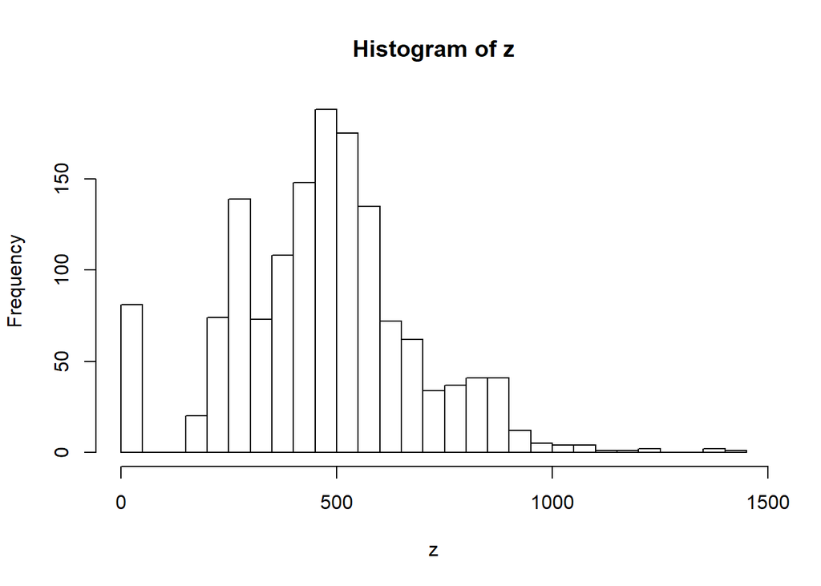

```r
hist(z, breaks = 50)
```

Then load the MASS package and run fitdistr to fit an exponential probability density function.  
(See https://stat.ethz.ch/R-manual/R-devel/library/MASS/html/fitdistr.html ).

```r
# Fit an exponential probability density function
fit_exp = fitdistr(z, densfun = "exponential")
print(fit_exp)
```

```
##        rate
##   2.114254e-03
##  (5.533255e-05)
```

Find the optimal value of lambda for this distribution, and then take 1000 samples from this exponential distribution using this value (e.g., rexp(1000, lambda)).

```r
# Get 1000 samples from the exponential distribution
fit_exp$estimate
```

```
##        rate
## 0.002114254
```

```r
samp = rexp(1000, fit_exp$estimate)
```

Plot a histogram and compare it with a histogram of your original variable.

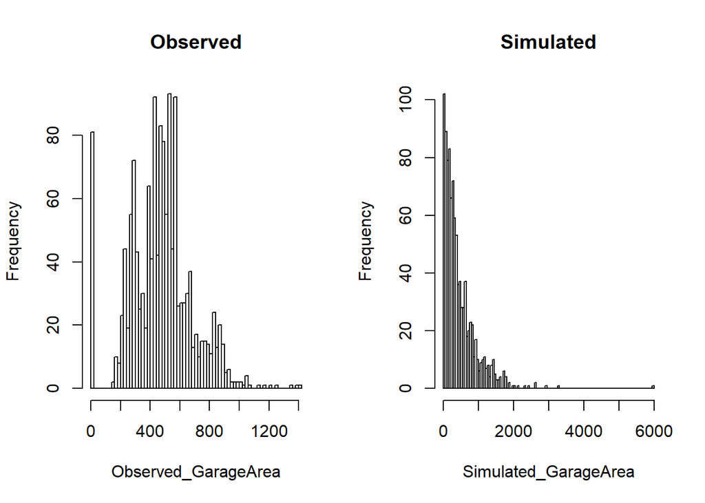

```r
# Plot a histogram of the observed and the simulated data
par(mfrow=c(1,2))
hist(z, breaks = 100, xlab = "Observed_GarageArea", main = "Observed")
hist(samp, breaks = 100, xlab = "Simulated_GarageArea", main = "Simulated")
```

*Visually from the histograms the simulated data is more heavily skewed to the right while the observed data is more concentrated to the centre.*

Using the exponential pdf, find the 5th and 95th percentiles using the cumulative distribution function (CDF).

```r
# Find the 5th and 95th percentile of the simulated sample data
quantile(samp, probs = c(0.05, 0.95))
```

```
##         5%        95%
##   23.98491 1369.76609
```

Also generate a 95% confidence interval from the empirical data, assuming normality.

```r
# Calculating the 95% confidence interval on the observed data
mean_z = mean(z)
n_z = nrow(z)
sd_z = sd(z)

se = qnorm(0.975) * sd_z/sqrt(n)

left_int = mean_z - se
print(left_int)
```

```
## [1] 468.7896
```

```r
right_int = mean_z + se
print(right_int)
```

```
## [1] 477.1706
```

*The 95% confidence interval lies between 468.79 and 477.17.*

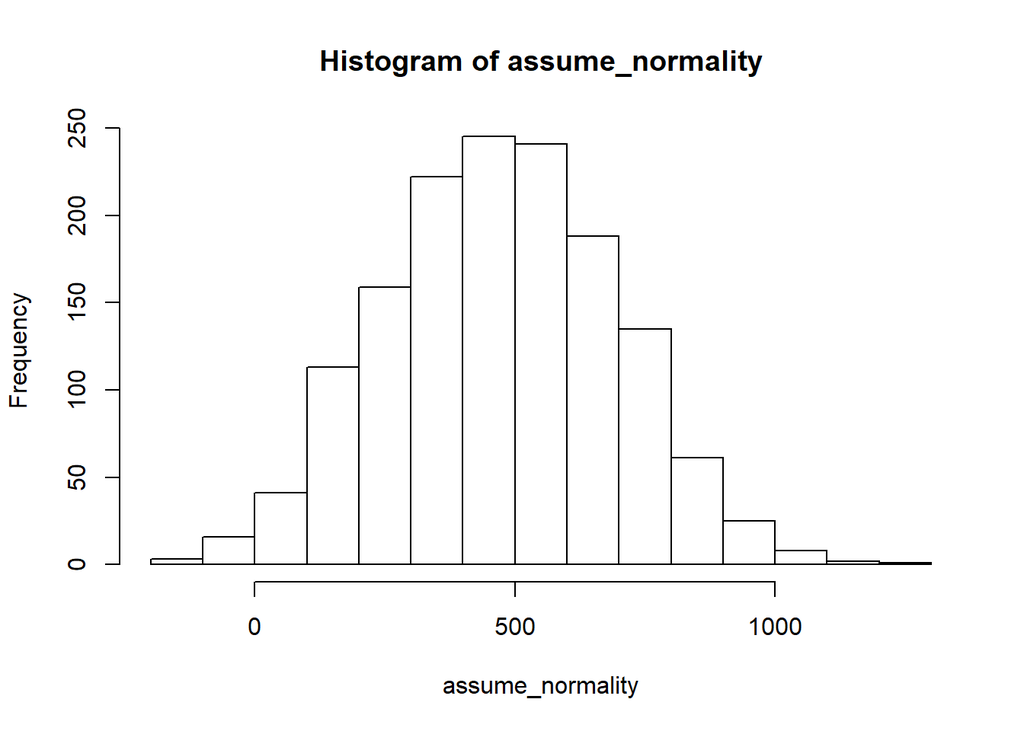

```r
# We plot a histogram to show the assumed normality
assume_normality = rnorm(length(z), mean_z, sd_z)
hist(assume_normality)
```

Finally, provide the empirical 5th percentile and 95th percentile of the data. Discuss.

```r
# Emperical 5th and 95th percentile of the observed data
quantile(z, probs = c(0.05, 0.95))
```

```
##    5%   95%
##   0.0 850.1
```

# Modeling.

Build some type of multiple regression model and submit your model to the competition board.  
Provide your complete model summary and results with analysis.

## Training Data and Model Generation

```r
#Load Training data set into a data frame and review the summary statistics for missing and or limited features.
hd_tr = read.csv("https://raw.githubusercontent.com/igukusamuel/DATA-605-Final-Project/master/train.csv")

summary(hd_tr)
```

```
##        Id           MSSubClass       MSZoning     LotFrontage
##  Min.   :   1.0   Min.   : 20.0   C (all):  10   Min.   : 21.00
##  1st Qu.: 365.8   1st Qu.: 20.0   FV     :  65   1st Qu.: 59.00
##  Median : 730.5   Median : 50.0   RH     :  16   Median : 69.00
##  Mean   : 730.5   Mean   : 56.9   RL     :1151   Mean   : 70.05
##  3rd Qu.:1095.2   3rd Qu.: 70.0   RM     : 218   3rd Qu.: 80.00
##  Max.   :1460.0   Max.   :190.0                  Max.   :313.00
##                                                  NA's   :259
##     LotArea        Street      Alley      LotShape  LandContour
##  Min.   :  1300   Grvl:   6   Grvl:  50   IR1:484   Bnk:  63
##  1st Qu.:  7554   Pave:1454   Pave:  41   IR2: 41   HLS:  50
##  Median :  9478               NA's:1369   IR3: 10   Low:  36
##  Mean   : 10517                           Reg:925   Lvl:1311
##  3rd Qu.: 11602
##  Max.   :215245
##
##   Utilities      LotConfig    LandSlope   Neighborhood   Condition1
##  AllPub:1459   Corner : 263   Gtl:1382   NAmes  :225   Norm   :1260
##  NoSeWa:   1   CulDSac:  94   Mod:  65   CollgCr:150   Feedr  :  81
##                FR2    :  47   Sev:  13   OldTown:113   Artery :  48
##                FR3    :   4              Edwards:100   RRAn   :  26
##                Inside :1052              Somerst: 86   PosN   :  19
##                                          Gilbert: 79   RRAe   :  11
##                                          (Other):707   (Other):  15
##    Condition2     BldgType      HouseStyle   OverallQual
##  Norm   :1445   1Fam  :1220   1Story :726   Min.   : 1.000
##  Feedr  :   6   2fmCon:  31   2Story :445   1st Qu.: 5.000
##  Artery :   2   Duplex:  52   1.5Fin :154   Median : 6.000
##  PosN   :   2   Twnhs :  43   SLvl   : 65   Mean   : 6.099
##  RRNn   :   2   TwnhsE: 114   SFoyer : 37   3rd Qu.: 7.000
##  PosA   :   1                 1.5Unf : 14   Max.   :10.000
##  (Other):   2                 (Other): 19
##   OverallCond      YearBuilt     YearRemodAdd    RoofStyle
##  Min.   :1.000   Min.   :1872   Min.   :1950   Flat   :  13
##  1st Qu.:5.000   1st Qu.:1954   1st Qu.:1967   Gable  :1141
##  Median :5.000   Median :1973   Median :1994   Gambrel:  11
##  Mean   :5.575   Mean   :1971   Mean   :1985   Hip    : 286
##  3rd Qu.:6.000   3rd Qu.:2000   3rd Qu.:2004   Mansard:   7
##  Max.   :9.000   Max.   :2010   Max.   :2010   Shed   :   2
##
```

[output cut: 89 more lines]

```
##  GdPrv:  59   Gar2:   2   Min.   :    0.00   Min.   : 1.000
##  GdWo :  54   Othr:   2   1st Qu.:    0.00   1st Qu.: 5.000
##  MnPrv: 157   Shed:  49   Median :    0.00   Median : 6.000
##  MnWw :  11   TenC:   1   Mean   :   43.49   Mean   : 6.322
##  NA's :1179   NA's:1406   3rd Qu.:    0.00   3rd Qu.: 8.000
##                           Max.   :15500.00   Max.   :12.000
##
##      YrSold        SaleType    SaleCondition    SalePrice
##  Min.   :2006   WD     :1267   Abnorml: 101   Min.   : 34900
##  1st Qu.:2007   New    : 122   AdjLand:   4   1st Qu.:129975
##  Median :2008   COD    :  43   Alloca :  12   Median :163000
##  Mean   :2008   ConLD  :   9   Family :  20   Mean   :180921
##  3rd Qu.:2009   ConLI  :   5   Normal :1198   3rd Qu.:214000
##  Max.   :2010   ConLw  :   5   Partial: 125   Max.   :755000
##                 (Other):   9
```

Load the selected variables into a dataframe and perform data cleanup operations.

```r
# Remove features with missing or limited data as evaluated from the summary statistics above.
hd_train <- hd_tr[, c("MSSubClass", "MSZoning", "LotArea", "LotShape", "LotConfig", "Neighborhood", "Condition1",
                      "Street", "BldgType", "HouseStyle", "OverallQual", "OverallCond", "YearBuilt", "YearRemodAdd",
                      "RoofStyle", "Exterior2nd", "MasVnrType", "ExterQual", "BsmtQual", "BsmtCond", "BsmtExposure",
                      "BsmtFinType1", "BsmtFinSF1", "BsmtFinType2", "TotalBsmtSF", "HeatingQC", "Electrical",
                      "X1stFlrSF", "GrLivArea", "BsmtFullBath", "BsmtHalfBath", "FullBath", "HalfBath", "BedroomAbvGr",
                      "KitchenAbvGr", "KitchenQual", "TotRmsAbvGrd", "Functional", "GarageArea", "PavedDrive",
                      "WoodDeckSF", "OpenPorchSF", "YrSold", "SaleType", "SaleCondition", "SalePrice")]


# Remove all Na's from the training data set
hd_train = na.omit(hd_train)

# Generate an initial regression model
Model_1 = lm(SalePrice ~ ., data = hd_train)

# Generate Summary Statisics
summary(Model_1)
```

```
##
## Call:
## lm(formula = SalePrice ~ ., data = hd_train)
##
## Residuals:
##     Min      1Q  Median      3Q     Max
## -344189  -11532       0   10881  211337
##
## Coefficients:
##                        Estimate Std. Error t value Pr(>|t|)
## (Intercept)           4.434e+05  1.283e+06   0.346 0.729647
## MSSubClass           -1.102e+02  1.010e+02  -1.091 0.275645
## MSZoningFV            2.985e+04  1.468e+04   2.033 0.042284 *
## MSZoningRH            1.971e+04  1.461e+04   1.349 0.177597
## MSZoningRL            2.334e+04  1.241e+04   1.881 0.060260 .
## MSZoningRM            2.360e+04  1.161e+04   2.033 0.042245 *
## LotArea               4.435e-01  1.036e-01   4.282 1.99e-05 ***
## LotShapeIR2           8.458e+03  5.179e+03   1.633 0.102682
## LotShapeIR3          -3.270e+04  1.050e+04  -3.114 0.001888 **
## LotShapeReg           1.593e+03  1.975e+03   0.806 0.420183
## LotConfigCulDSac      1.134e+04  3.955e+03   2.867 0.004217 **
## LotConfigFR2         -9.935e+03  5.001e+03  -1.987 0.047184 *
## LotConfigFR3         -2.174e+04  1.546e+04  -1.407 0.159797
## LotConfigInside      -1.358e+03  2.158e+03  -0.629 0.529412
## NeighborhoodBlueste  -1.309e+02  2.353e+04  -0.006 0.995561
## NeighborhoodBrDale    5.567e+03  1.323e+04   0.421 0.674005
## NeighborhoodBrkSide  -3.007e+03  1.140e+04  -0.264 0.792074
## NeighborhoodClearCr  -6.810e+03  1.121e+04  -0.608 0.543542
## NeighborhoodCollgCr  -6.176e+03  8.749e+03  -0.706 0.480382
## NeighborhoodCrawfor   2.075e+04  1.029e+04   2.017 0.043902 *
## NeighborhoodEdwards  -2.309e+04  9.730e+03  -2.373 0.017784 *
## NeighborhoodGilbert  -4.705e+03  9.461e+03  -0.497 0.619084
## NeighborhoodIDOTRR   -1.306e+04  1.294e+04  -1.009 0.313128
## NeighborhoodMeadowV  -5.162e+03  1.355e+04  -0.381 0.703306
## NeighborhoodMitchel  -1.729e+04  9.970e+03  -1.734 0.083119 .
## NeighborhoodNAmes    -1.207e+04  9.448e+03  -1.277 0.201842
## NeighborhoodNoRidge   4.720e+04  1.004e+04   4.702 2.86e-06 ***
## NeighborhoodNPkVill   1.483e+04  1.602e+04   0.925 0.354910
## NeighborhoodNridgHt   3.011e+04  8.908e+03   3.380 0.000748 ***
## NeighborhoodNWAmes   -1.001e+04  9.689e+03  -1.033 0.301954
```

[output cut: 115 more lines]

```
## SaleTypeCWD           1.157e+04  1.594e+04   0.726 0.468074
## SaleTypeNew           3.558e+04  1.886e+04   1.886 0.059520 .
## SaleTypeOth           1.567e+04  1.798e+04   0.871 0.383784
## SaleTypeWD            1.542e+03  5.169e+03   0.298 0.765576
## SaleConditionAdjLand  1.398e+04  1.921e+04   0.728 0.467035
## SaleConditionAlloca   2.442e+04  1.195e+04   2.043 0.041233 *
## SaleConditionFamily  -7.976e+02  7.540e+03  -0.106 0.915771
## SaleConditionNormal   6.515e+03  3.528e+03   1.847 0.065016 .
## SaleConditionPartial -1.804e+04  1.818e+04  -0.992 0.321186
## ---
## Signif. codes:  0 '***' 0.001 '**' 0.01 '*' 0.05 '.' 0.1 ' ' 1
##
## Residual standard error: 28670 on 1258 degrees of freedom
## Multiple R-squared:  0.8833, Adjusted R-squared:  0.8692
## F-statistic: 62.26 on 153 and 1258 DF,  p-value: < 2.2e-16
```

The model produces a Multiple R-Squared of 0.8833 which is great. We can interpret this to mean that 88.33% variance in the saleprice van be explained by the predictor variables in the current model. The F-Statistic is 62.26 on 153 and 1258 degrees of freedom. The p-value is very small.

## Model Testing and submission

Let us test how good our model performs on the test data set.

```r
# Load Testing set
hd_test = read.csv("https://raw.githubusercontent.com/igukusamuel/DATA-605-Final-Project/master/test.csv")

# Predict the saleprice for the testing data set
PredictedDataModel = hd_test
PredictedDataModel$SalePrice = predict(Model_1, hd_test)

# Set the Id and SalePrice colums to be loaded into Kaggle Data Frame
Id = hd_test$Id
SalePrice = PredictedDataModel$SalePrice

# Combine the ID and the model predicted SalePrice values
DF = data.frame(cbind(Id, SalePrice))

# Replace all missing values with 0 in the final Data Frame
DF[is.na(DF)] = 0
DF = replace(DF, is.na(DF), 0)

#View the first 5 rows of the data frame
print(head(DF, 5))
```

```
##     Id SalePrice
## 1 1461  112727.4
## 2 1462  162637.4
## 3 1463  170295.3
## 4 1464  188793.8
## 5 1465  213258.2
```

```r
# Write the predicted values into a .csv file for submission.
#write.csv(DF, file = "KaggleData_Model_Prediction.csv", row.names = FALSE)
```

## Kaggle Submission - Score

Report your Kaggle.com user name and score.

Kaggle Username: Samuel Kigamba

Kaggle Score: 2.50090

See submission documents : https://github.com/igukusamuel/DATA-605-Final-Project

[figure not shown]